# Barcoder Parameters

Created July 17, 2020

PME

17 July, 2020, 13:41

# Overview

`guppy_barcoder` has a number of options to optimize binning. These include:

- `--min_score` (60)
- `--require_both_ends` (FALSE)
- `--min_score_rear_override`
- `--detect_mid_strand_barcodes` (FALSE)
- `--min_score_mid_barcodes` (50)
- `--front_window_size` (50)
- `--rear_window_size`

Gap penalties can also be modified for starting (40), opening (40), extending (40), and ending (40).

The scores are calculated by modified Needleman-Wunsch algorithm, and normalized by the length of the barcode sequence. Scores for matches and mismatches are (available in /opt/ont/guppy/data/barcoding):

`. A C G T N`

`A 96 -316 -192 -369 0`

`C -316 100 -352 -295 0`

`G -192 -352 98 -329 0`

`T -369 -295 -329 100 0`

`N 0 0 0 0 0` `

Because scores are normalized, the highest possible score is 100. The highest score barcode is considered a candidate match, which if above `--min_score`, is considered successful.

`guppy_barcoder` produces a summary table for each read, which includes the read id, barcode matches, sequences, and scores, etc. We’ll use that to set a proper threshold given our knowledge of the samples.

```r
libs = c('here', 'magrittr', 'ggplot2', 'reshape2')

for (i in libs) library(i, character.only=TRUE)

df = here('Data', 'barcoding_summary.txt') %>%
  read.table(header=TRUE, stringsAsFactors=FALSE)

meta = here('Data', 'MinION CLC Barcodes.csv') %>%
  read.csv(stringsAsFactors=FALSE)
```

The summary has a lot of columns. Let’s clean this up.

```r
keep_cols = c('read_id',
              'barcode_arrangement',
              'barcode_front_id',
              'barcode_front_score',
              'barcode_front_foundseq_length',
              'barcode_rear_id',
              'barcode_rear_score',
              'barcode_rear_foundseq_length')

df = df[keep_cols]
names(df) %<>% gsub('barcode_', '', .) %>%
  gsub('foundseq_', '', .) %>%
  gsub('arrangement', 'barcode', .)

df$barcode %<>% gsub('barcode', 'BC', .)

df$front_id %<>% gsub('_FWD', '', .)
df$rear_id %<>% gsub('_REV', '', .)

df %<>%
  merge(meta[, c('BARCODE', 'TYPE')],
        by.x='barcode',
        by.y='BARCODE',
        all=TRUE)

head(df)
```

|  | barcode | read_id | front_id | front_score | front_length | rear_id | rear_score | rear_length | TYPE |
| --- | --- | --- | --- | --- | --- | --- | --- | --- | --- |
| 1 | BC01 | 696c280e-b1ab-47d5-b515-f7685c810ab2 | BC01 | 79.3192 | 63 | BC01 | 88.30000 | 60 | sample |
| 2 | BC01 | 8fdcda28-b8ec-47a6-bfbd-51ce507ebe3e | BC01 | 83.2333 | 58 | BC01 | 45.39550 | 60 | sample |
| 3 | BC01 | 978e7ced-8adb-4be4-a00e-8db218181910 | BC01 | 58.8432 | 67 | BC01 | 93.10000 | 60 | sample |
| 4 | BC01 | 0a69226a-4c1c-422e-91f9-b99199b5cd3d | BC01 | 98.9000 | 60 | BC01 | 61.72880 | 47 | sample |
| 5 | BC01 | 8855ba94-fd23-4455-bc1f-4a7015bb673e | BC01 | 87.9292 | 61 | BC01 | -2.27119 | 46 | sample |
| 6 | BC01 | 2a68b08b-8ef9-41bd-a801-247276c5ef73 | BC01 | 94.2333 | 58 | BC01 | 16.40680 | 59 | sample |

## Score and length distributions

Now we’ll look at the distributions of scores and lengths matched for each location.

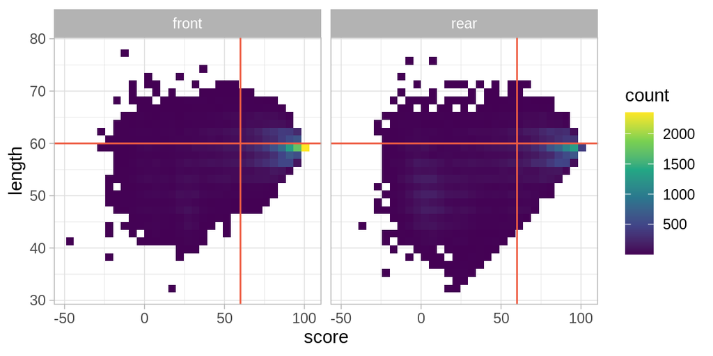

```r
pltdf = rbind(
  data.frame(df[, c('front_length',
                    'front_score')] %>%
               set_names(c('length', 'score')),
             location = 'front'
             ),
  data.frame(df[, c('rear_length',
                    'rear_score')] %>%
               set_names(c('length', 'score')),
             location = 'rear'
             )
)

ggplot(pltdf,
       aes(x=score,
           y=length)) +
  facet_wrap(~location) +
  scale_fill_continuous(type='viridis') +
  geom_bin2d() +
  geom_vline(aes(xintercept=60), color='tomato2') +
  geom_hline(aes(yintercept=60), color='tomato2') +
  theme_light()
```

The vertical line is the default minimum score. We can see that the rear barcodes don’t fare as well - they tend to be of lower quality, and lower matched length. The horizontal line is the expected length (60 bp). Scores are scaled so that a perfect match across all bases is 100.

Looking at the profile of these shapes highlights how the rear barcode is generally of lower quality.

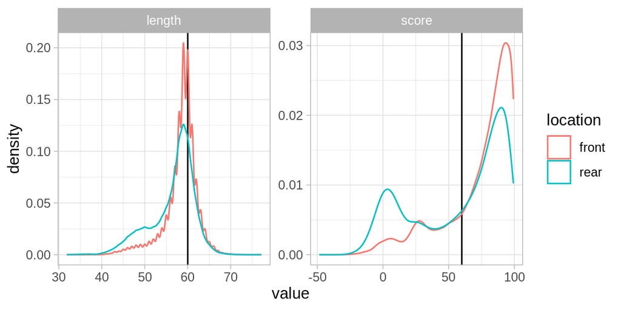

```r
ggplot(data=melt(pltdf),
       aes(x=value,
           color=location)) +
  facet_wrap(~variable,
             scales='free') +
  geom_vline(aes(xintercept=60)) +
  geom_density() +
  theme_light()
```

Currently, we are requiring a minimum score of 60 for both front and rear barcodes. This will remove a number of samples, possibly unnecessarily. The proportion of excluded reads based on the front or the rear are:

```r
nr = nrow(df)
find_p = function(x, val) {
  x %<>% na.omit
  out = sum(x < val) / length(x)
  return(out)
}
c(front = find_p(df$front_score, 60),
  rear = find_p(df$rear_score, 60)) %>%
  round(3)
```

```
## front  rear
## 0.231 0.410
```

So at least 18% of reads are excluded based on a poor rear barcode score.

To run some comparisions, we need to make a few variables:

1. whether the front and rear agree
2. the score to use when requiring a minimum score at both ends.

```r
df$agree = df$front_id == df$rear_id
df$both_score = apply(df[, c('front_score', 'rear_score')], 1, function(x) min(x[1], x[2]))# keep minimum score
```

# Test Parameters

## Approach

We want to maximize read retention, while minimizing false assignments. Luckily, we have a number of “blanks” - barcodes that *should* be empty.

Therefore, as we vary the minimum score for the front, rear, or both, we will:

1. Count the number of reads that are retained.
2. Count the number of reads assigned to blanks.

The trick is converting the false assignment number to a standardized number that accounts for the expected rate. To identify an approahc to this, we’ll generate some data: 96 barcodes, 10000 sequences, and process it using two scenarios:

1. 6 blank barcodes. How many blanks would we expect to observe, given completely random assignments?
2. All good barcodes. How much agreement would we expect, given completely random assignments?

This will provide a “randomness” factor.

```r
bc = seq_len(96)
bad_bc = seq_len(6)
nseq = 10000

truth = sample(bc, nseq, replace=TRUE)
perms = sapply(seq_len(100), function(x) sample(bc, nseq, replace=TRUE))
```

```r
misassign = apply(perms, c(1,2), function(x) x %in% bad_bc)
misassign = colSums(misassign)/nrow(misassign)

mis1 = apply(perms, 2, function(x) x == truth)
mis1 = colSums(mis1)/nrow(mis1)

t.test(misassign/6, mis1)
```

```
##
##  Welch Two Sample t-test
##
## data:  misassign/6 and mis1
## t = -2.06, df = 130.62, p-value = 0.04138
## alternative hypothesis: true difference in means is not equal to 0
## 95 percent confidence interval:
##  -4.459717e-04 -9.028251e-06
## sample estimates:
## mean of x mean of y
## 0.0103475 0.0105750
```

## Test

We’ll graph the response of assignment and misassignment given a few variables:

1. Increasing minimum score
2. Requiring a front, rear, or both barcodes to be above that minimum score.

The function below will assign a barcode to a read given a cutoff and barcode location. It then returns the proporitons of misasigned, blanks, and assigned reads.

```r
blanks = subset(meta, TYPE=='blank')[, 'BARCODE']

assign_barcode = function(x, location, cutoff, blanks) {
  x = na.omit(x)
  nblanks = length(blanks)
  nbarcodes = 96
  max_blanks = nblanks/nbarcodes
  max_misassign = (nbarcodes-1)/nbarcodes

  nreads = nrow(x)
  score_name = paste0(location, '_score')
  x$ASSIGN = ifelse(x[, score_name] >= cutoff, x[, 'barcode'], 'Unassigned')

  p_assign = sum(x$ASSIGN != 'Unassigned')/nreads
  p_blanks = sum(x$ASSIGN %in% blanks)/nreads

  p_misassign = max_misassign * p_blanks * max_blanks

  out = c(cutoff = cutoff,
          p_assign = p_assign,
          p_blanks = p_blanks,
          p_misassign = p_misassign)
  return(out)
}
```

We’ll run this function across cutoff scores of -100 to 100 (the minimum and maximum possible), requiring scores to be greater than or equal to the cutoff for the front, rear, or both locations.

```r
scores = c(-100:100)
vals = c('front', 'rear', 'both') %>%
  lapply(function(y) {
    out = sapply(scores, function(x) assign_barcode(df, y, x, blanks)) %>%
      t %>%
      data.frame(location = y)
  }) %>%
  do.call(rbind, .)
summary(vals)
```

```
##      cutoff        p_assign         p_blanks          p_misassign
##  Min.   :-100   Min.   :0.0000   Min.   :0.0000000   Min.   :0.000e+00
##  1st Qu.: -50   1st Qu.:0.7644   1st Qu.:0.0000000   1st Qu.:0.000e+00
##  Median :   0   Median :0.9847   Median :0.0001510   Median :9.341e-06
##  Mean   :   0   Mean   :0.8385   Mean   :0.0001032   Mean   :6.382e-06
##  3rd Qu.:  50   3rd Qu.:1.0000   3rd Qu.:0.0001510   3rd Qu.:9.341e-06
##  Max.   : 100   Max.   :1.0000   Max.   :0.0001510   Max.   :9.341e-06
##   location
##  front:201
##  rear :201
##  both :201
##
##
##
```

We can see that very few reads are misassigned, in any scenario. This is likely due to our small sample size (19864 reads).

## Results

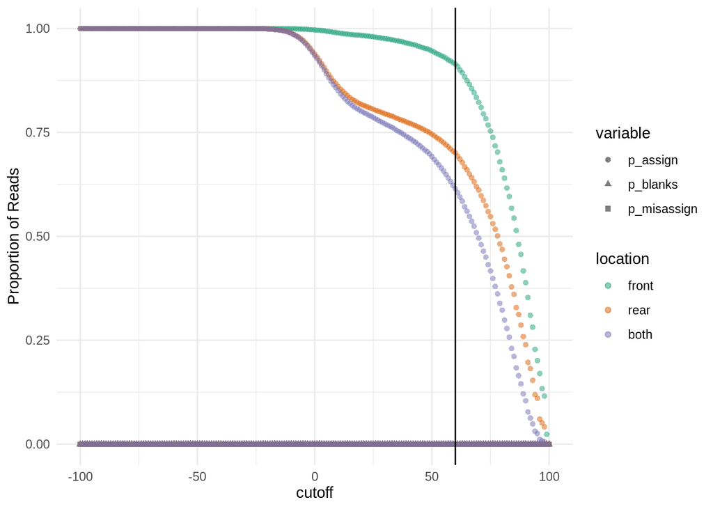

```r
pltdf = melt(vals, id.vars=c('cutoff', 'location'))
ggplot(data=pltdf,
       aes(x=cutoff,
           y=value,
           color=location,
           shape=variable)) +
  scale_color_brewer(palette='Dark2') +
  ylab('Proportion of Reads') +
  geom_point(alpha=0.5) +
  geom_vline(aes(xintercept=60)) +
  theme_minimal()
```

The cutoff value of 60 is right at the break point of the front barcode. The cutoff of 50 is good for the rear. Both is quite stringent. However, in all cases, basically no barcodes are misassigned.

# Summary

This suggests that: